# Get more experience with R

Group 4

15 maart, 2025

# Introduction

In this R-challenge we would first like to reproduce a volcano plot from an article using the provided supplementary data and then apply some of the skills we have learned in the previous weeks. Basically, in the same article, the authors also provide a matrix with the expression of the proteins in the surfaceome of multiple myeloma cells. We will try to visualize this matrix as a heatmap, a correlation heatmap or a PCA/MDS plot.

**Article: The surfaceome of multiple myeloma cells suggests potential immunotherapeutic strategies and protein markers of drug resistance** DOI: 10.1038/s41467-022-31810-6

The article “The surfaceome of multiple myeloma cells suggests potential immunotherapeutic strategies and protein markers of drug resistance” by Ferguson et al. presents a comprehensive investigation of the surface proteome, or surfaceome, of multiple myeloma cells. This study is pivotal as it explores how the surfaceome influences the interaction between tumor cells and their microenvironment, making it a critical area for potential therapeutic advancements and understanding drug resistance mechanisms (Ferguson et al. 2022).

The authors employed glycoprotein capture proteomics to systematically characterize the myeloma surfaceome under various conditions: at baseline, when facing drug resistance, and in response to acute drug treatments. This methodology allowed for a detailed examination of surface antigens that could be targeted for immunotherapy. The findings from this study include the establishment of a scoring system to evaluate and prioritize these surface antigens based on their potential therapeutic value (Ferguson et al. 2022).

One of the most significant outcomes of the study is the identification of CCR10 as a promising target for immunotherapeutic intervention. The expression of CCR10 was noted to be prevalent among malignant plasma cells, suggesting that therapies targeting this marker could enhance treatment efficacy. This provides a strategic direction for developing new immunotherapies aimed specifically at overcoming the challenges associated with drug resistance in multiple myeloma (Ferguson et al. 2022).

Overall, the article provides vital insights into the complexity of the myeloma surfaceome and reinforces the need for continued exploration into targeted therapies that can improve clinical outcomes in patients suffering from multiple myeloma. *the article (pdf) is available in the folder of this tutorial*

## Libraries used for this tutorial:

You may not need all of these listed here.

- tidyr, dplyr: data handling from the tidyverse
- magrittr: together with tidyverse it allows the use of %<>%
- readxl and openxlsx: libraries to open and write microsoft excel files
- ggplot2: produce nice plots
- pheatmap: to great nice (pretty) heatmaps from matrices
- ggtree: to plot phylogenetic trees
- ape: to read and manipulate phylogenetic trees
- viridis: to get nice color scales
- DESeq2, plotly, limma, SummarizedExperiment: to generate similar QC plots as in week 2
- ggrepel: to avoid overplotting of labels in ggplot2

## Idea in this R-challenge:

- Find the excel sheet, look at it, see what is relevant and then try to do the coding
- One sheet in this excel book is relevant but only part of it, try to restructure it R the way you need it
- Try to use AI in this challenge at multiple steps (restructure the data, plotting w/ ggplot) if it is not immediately obvious to you how to do it.

# Goal 1: Redo Figure 1E from the article

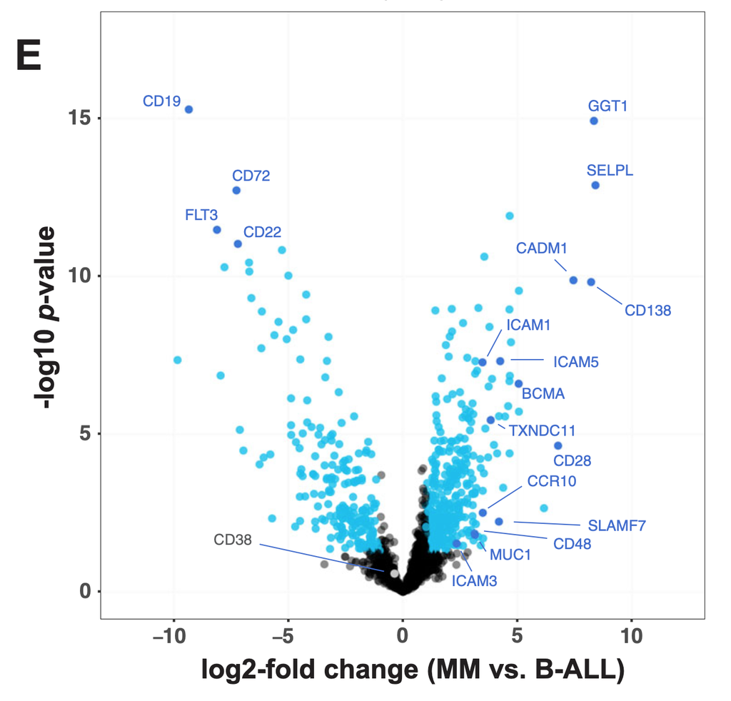

NatCom: Ferguson et. al, Figure 1E

```
##   Uniprot_ID   AMO1.1   AMO1.2   AMO1.3 ARH77.WT.1 ARH77.WT.2 ARH77.WT.3
## 1     Q14242 28.67624 30.81230 30.23695   26.55964   27.70965   26.90369
## 2     P19440 29.67649 30.94133 30.25372   28.62906   28.06353   28.60233
## 3     P18827 33.71590 32.32809 32.71447   24.33967   27.73867   25.68659
## 4     Q9BY67 27.98718 26.04510 27.49747   22.24933   19.17515   21.63909
## 5     P10747 29.85359 29.13997 27.91792   20.09964   21.96183   21.07814
## 6     Q12860 19.73732 20.07692 19.41152   29.08621   28.76948   29.93649
##    Bcell.1  Bcell.2  Bcell.3    BEL.1    BEL.2    BEL.3  KMS12.1  KMS12.2
## 1 25.32251 27.05672 26.89989 20.75620 25.45341 21.16745 26.68966 28.88373
## 2 27.99766 29.23695 27.99026 21.24874 20.02910 24.93008 28.30064 29.95199
## 3 27.90873 27.20946 26.74817 21.50345 21.09715 21.13692 28.09083 28.14938
## 4 24.28115 19.12573 20.05651 22.19637 20.58466 20.22888 25.79882 28.87168
## 5 20.82174 20.69627 20.54902 21.47702 20.07415 20.55226 21.04727 23.06712
## 6 24.12550 26.67088 27.18442 19.99369 20.09854 19.97071 20.91583 23.80509
##    KMS12.3  KOPN8.1  KOPN8.2  KOPN8.3 L363.WT.1 L363.WT.2    REH.1    REH.2
```

[output cut: 41 more lines]

```
## [1] "here we look into head of the data"
```

```
##    Gene log2Ratio       Pvalue
## 1 SELPL  8.413062 1.300592e-13
## 2  GGT1  8.340996 1.178002e-15
## 3 CD138  8.215638 1.510770e-10
## 4 CADM1  7.450760 1.330640e-10
## 5  CD28  6.772585 2.314554e-05
## 6 CNTN1  6.157261 2.227425e-03
```

```
## [1] "look into reshaped data"
```

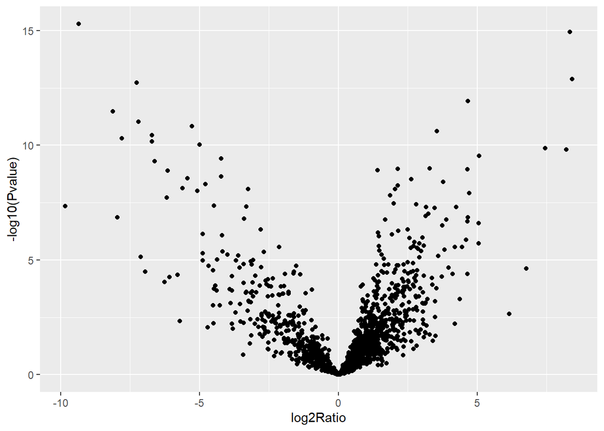

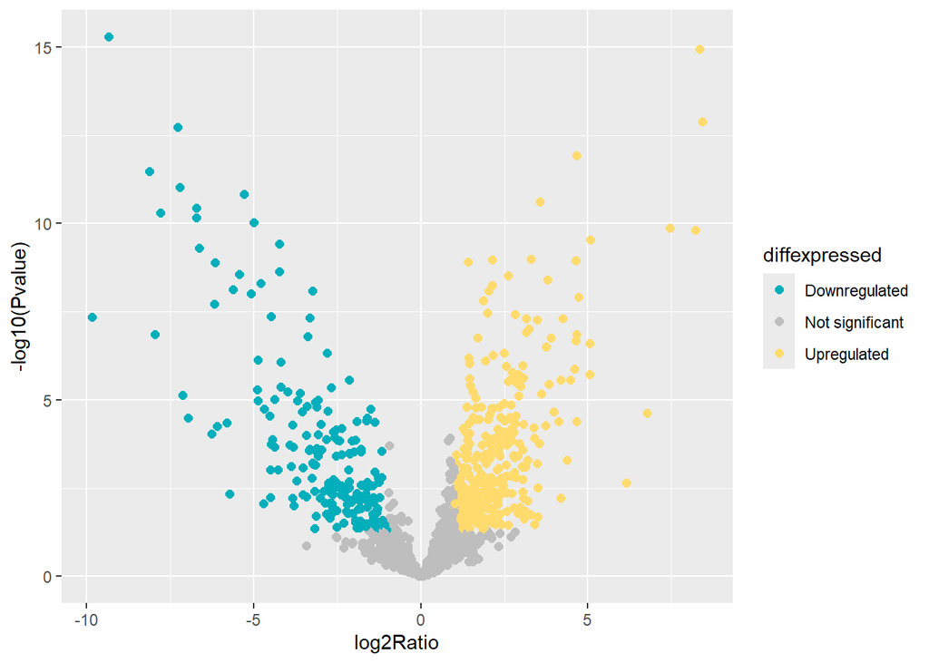

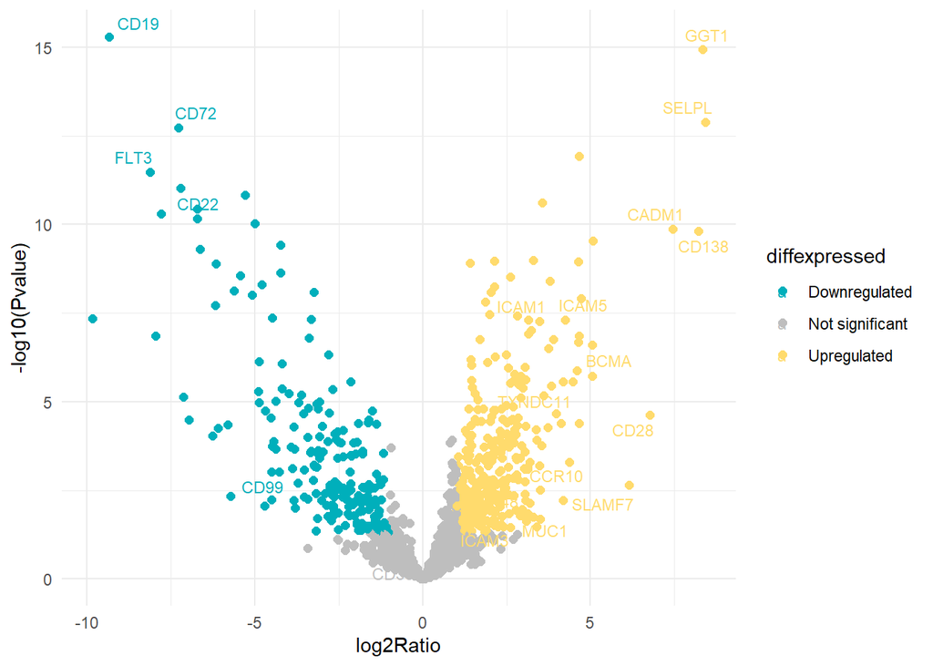

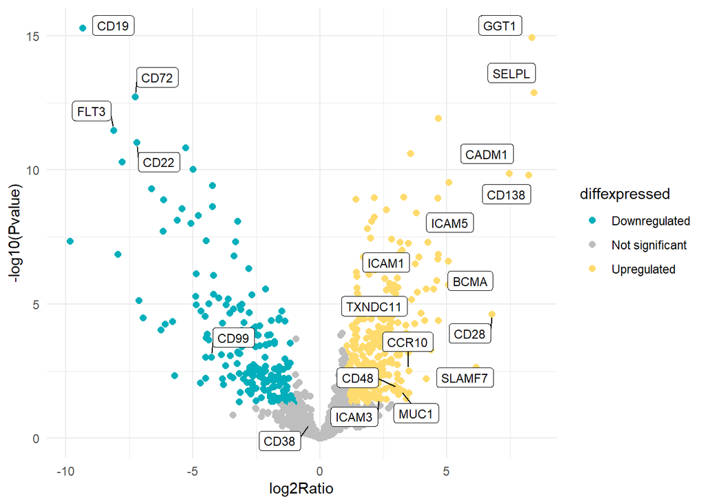

# Goal 2: Try to visualize the expression matrix as a heatmap and make some QC plots

The authors of the article also provide a matrix with the expression of the proteins in the surfaceome of multiple myeloma cells. Please also remember the QC-plots from week 3. We will try to visualize this matrix as a heatmap and do some more QC plots such as correlation heatmap or a PCA/MDS plot.

```r
# Do you find a pattern that matches all the columns that you want? There is a regEx pattern that matches the columns of interest
dat_wide <- dat |> select(Protein, matches("\\.\\d+$"))
head(dat_wide)
```

```
##   Protein   AMO1.1   AMO1.2   AMO1.3 ARH77.WT.1 ARH77.WT.2 ARH77.WT.3  Bcell.1
## 1   SELPL 28.67624 30.81230 30.23695   26.55964   27.70965   26.90369 25.32251
## 2    GGT1 29.67649 30.94133 30.25372   28.62906   28.06353   28.60233 27.99766
## 3   CD138 33.71590 32.32809 32.71447   24.33967   27.73867   25.68659 27.90873
## 4   CADM1 27.98718 26.04510 27.49747   22.24933   19.17515   21.63909 24.28115
## 5    CD28 29.85359 29.13997 27.91792   20.09964   21.96183   21.07814 20.82174
## 6   CNTN1 19.73732 20.07692 19.41152   29.08621   28.76948   29.93649 24.12550
##    Bcell.2  Bcell.3    BEL.1    BEL.2    BEL.3  KMS12.1  KMS12.2  KMS12.3
## 1 27.05672 26.89989 20.75620 25.45341 21.16745 26.68966 28.88373 28.32646
## 2 29.23695 27.99026 21.24874 20.02910 24.93008 28.30064 29.95199 29.70696
## 3 27.20946 26.74817 21.50345 21.09715 21.13692 28.09083 28.14938 28.48693
## 4 19.12573 20.05651 22.19637 20.58466 20.22888 25.79882 28.87168 28.90003
## 5 20.69627 20.54902 21.47702 20.07415 20.55226 21.04727 23.06712 24.75832
## 6 26.67088 27.18442 19.99369 20.09854 19.97071 20.91583 23.80509 24.39021
##    KOPN8.1  KOPN8.2  KOPN8.3 L363.WT.1 L363.WT.2    REH.1    REH.2    REH.3
```

[output cut: 20 more lines]

First some reshaping is necessairy again.

### A heatmap with clustering

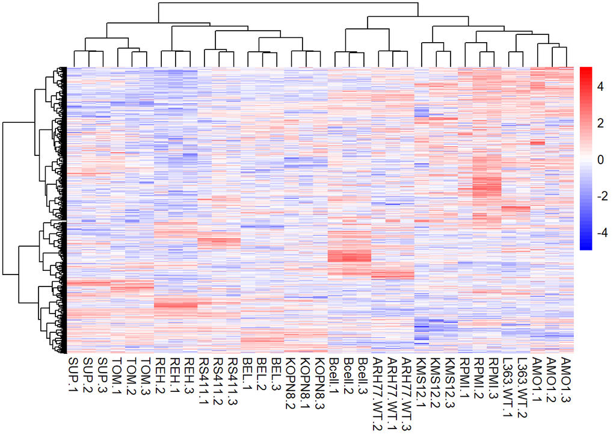

[output not shown]

[output cut: 161 more lines]

```
## REH.1      0.6612766 0.6724074 0.6537637 0.6902408 0.6824895
## REH.2      0.6716777 0.6803108 0.6700216 0.6979806 0.6910450
## REH.3      0.6575332 0.6693626 0.6590213 0.6894856 0.6839397
## RPMI.1     0.5557601 0.5678157 0.5911210 0.5828691 0.5724634
## RPMI.2     0.5152531 0.5294208 0.5451910 0.5160820 0.5106149
## RPMI.3     0.5197319 0.5308519 0.5473043 0.5288892 0.5201600
## RS411.1    0.6789776 0.6831723 0.6545871 0.6916846 0.6803568
## RS411.2    0.7118123 0.7172845 0.6805075 0.6826735 0.6792547
## RS411.3    0.6951701 0.6995512 0.6629048 0.6690111 0.6622789
## SUP.1      0.9277926 0.9299682 0.7807682 0.7964903 0.7944183
## SUP.2      1.0000000 0.9358329 0.7989009 0.7879440 0.7849826
## SUP.3      0.9358329 1.0000000 0.8000805 0.8013768 0.7989021
## TOM.1      0.7989009 0.8000805 1.0000000 0.9186264 0.9229903
## TOM.2      0.7879440 0.8013768 0.9186264 1.0000000 0.9386799
## TOM.3      0.7849826 0.7989021 0.9229903 0.9386799 1.0000000
```

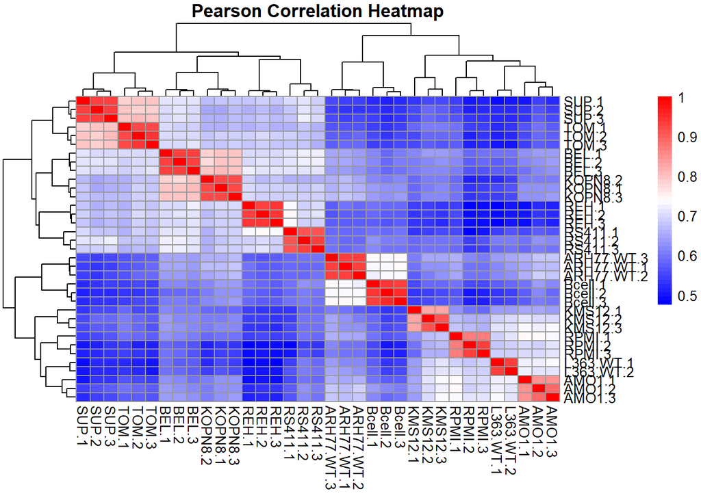

## Some QC plots like in week 3

### First again some reshaping

```r
# extract again relevant columns but here UniProt Ids (since unique) for all rows
dat_wide2 <- dat |> select(Uniprot_ID, matches("\\.\\d+$"))
# only quantitative matrix in a data frame and uniprot Ids as rownames
qMat <- dat_wide2 %>% select(-Uniprot_ID)
rownames(qMat) <- dat_wide$UniProt_ID
# qMat should have integer values to minimize rounding effect errors we multiply it with 100
qMat100 <- round(qMat*100, 0)


# extract conditions (cell types) from column names with regular expression
cellTypes <- gsub("\\.\\d+$", "", colnames(qMat100))

# Define meta dataframe for later use
meta <- data.frame(
  Condition=as.factor(cellTypes),
  row.names=colnames(qMat100)
)

conditionColours <- scales::hue_pal()(length(unique(meta$Condition)))
names(conditionColours) <- unique(meta$Condition)
sampleColours <- conditionColours[meta$Condition]

dds <- DESeq2::DESeqDataSetFromMatrix(countData=qMat100,
                                      colData=meta,
                                      design=~Condition)
vsd <- DESeq2::vst(dds)
```

```
## -- note: fitType='parametric', but the dispersion trend was not well captured by the
##    function: y = a/x + b, and a local regression fit was automatically substituted.
##    specify fitType='local' or 'mean' to avoid this message next time.
```

```r
# Extract normalized counts
vsdSE <- SummarizedExperiment::assay(vsd)
```

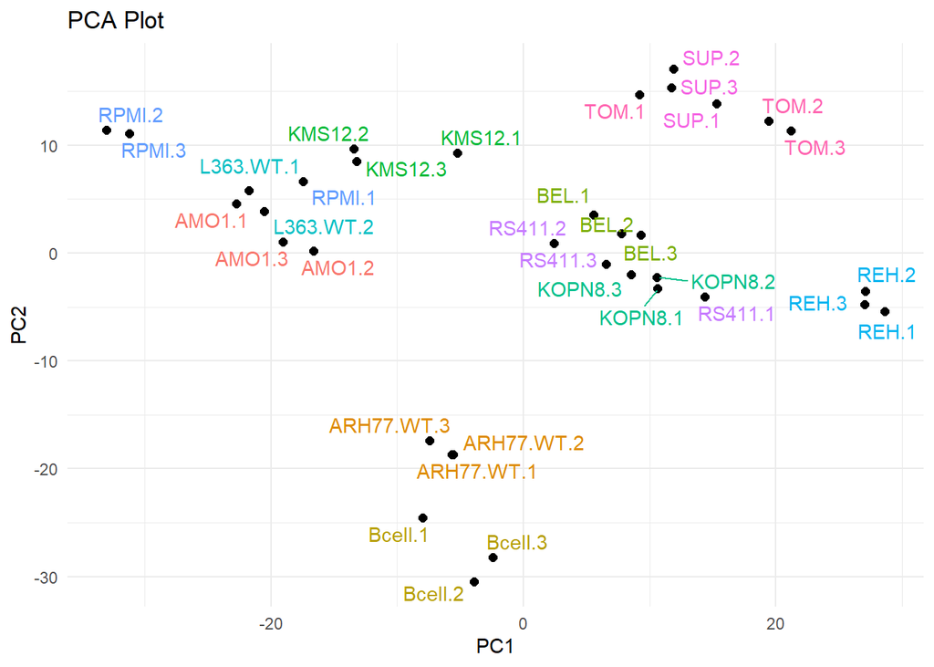

```r
# Do PCA
pca_result <- prcomp(t(dat_matrix), scale. = TRUE)
pca_data <- as.data.frame(pca_result$x)
pca_data$Sample <- rownames(pca_data)
pca_data$Group <- gsub("\\.\\d+$", "", pca_data$Sample)

ggplot(pca_data, aes(x = PC1, y = PC2, label = Sample, colour = Group)) +
  geom_point(size = 2, color = "black") +
  geom_text_repel() +
  theme_minimal() +
  labs(title = "PCA Plot", x = "PC1", y = "PC2") + theme(legend.position = "none")
```

### Correlation plot like in week 3

```r
# Pearson correlation plot
```

[output not shown]

# Session Information

Here we show the session information of the packages used in this tutorial as well as the references can be found below.

**R version 4.4.1 (2024-06-14 ucrt)**

**Platform:** x86_64-w64-mingw32/x64

**locale:** *LC_COLLATE=Dutch_Netherlands.utf8*, *LC_CTYPE=Dutch_Netherlands.utf8*, *LC_MONETARY=Dutch_Netherlands.utf8*, *LC_NUMERIC=C* and *LC_TIME=Dutch_Netherlands.utf8*

**attached base packages:** *stats4*, *stats*, *graphics*, *grDevices*, *utils*, *datasets*, *methods* and *base*

**other attached packages:** *limma(v.3.62.2)*, *plotly(v.4.10.4)*, *ape(v.5.8-1)*, *DESeq2(v.1.46.0)*, *magrittr(v.2.0.3)*, *RColorBrewer(v.1.1-3)*, *SummarizedExperiment(v.1.36.0)*, *Biobase(v.2.66.0)*, *GenomicRanges(v.1.58.0)*, *GenomeInfoDb(v.1.42.3)*, *IRanges(v.2.40.1)*, *S4Vectors(v.0.44.0)*, *BiocGenerics(v.0.52.0)*, *MatrixGenerics(v.1.18.1)*, *matrixStats(v.1.5.0)*, *pheatmap(v.1.0.12)*, *ggrepel(v.0.9.6)*, *viridis(v.0.6.5)*, *viridisLite(v.0.4.2)*, *ggtree(v.3.14.0)*, *openxlsx(v.4.2.8)*, *readxl(v.1.4.3)*, *lubridate(v.1.9.4)*, *forcats(v.1.0.0)*, *stringr(v.1.5.1)*, *dplyr(v.1.1.4)*, *purrr(v.1.0.4)*, *readr(v.2.1.5)*, *tidyr(v.1.3.1)*, *tibble(v.3.2.1)*, *ggplot2(v.3.5.1)*, *tidyverse(v.2.0.0)* and *BiocManager(v.1.30.25)*

**loaded via a namespace (and not attached):** *tidyselect(v.1.2.1)*, *farver(v.2.1.2)*, *fastmap(v.1.2.0)*, *lazyeval(v.0.2.2)*, *digest(v.0.6.37)*, *timechange(v.0.3.0)*, *lifecycle(v.1.0.4)*, *statmod(v.1.5.0)*, *tidytree(v.0.4.6)*, *compiler(v.4.4.1)*, *rlang(v.1.1.4)*, *sass(v.0.4.9)*, *tools(v.4.4.1)*, *yaml(v.2.3.10)*, *data.table(v.1.16.4)*, *knitr(v.1.49)*, *labeling(v.0.4.3)*, *htmlwidgets(v.1.6.4)*, *S4Arrays(v.1.6.0)*, *DelayedArray(v.0.32.0)*, *BiocParallel(v.1.40.0)*, *abind(v.1.4-8)*, *aplot(v.0.2.5)*, *withr(v.3.0.2)*, *grid(v.4.4.1)*, *colorspace(v.2.1-1)*, *scales(v.1.3.0)*, *cli(v.3.6.3)*, *crayon(v.1.5.3)*, *rmarkdown(v.2.29)*, *treeio(v.1.30.0)*, *generics(v.0.1.3)*, *rstudioapi(v.0.17.1)*, *httr(v.1.4.7)*, *tzdb(v.0.4.0)*, *cachem(v.1.1.0)*, *pander(v.0.6.5)*, *zlibbioc(v.1.52.0)*, *parallel(v.4.4.1)*, *ggplotify(v.0.1.2)*, *cellranger(v.1.1.0)*, *XVector(v.0.46.0)*, *yulab.utils(v.0.2.0)*, *vctrs(v.0.6.5)*, *Matrix(v.1.7-2)*, *jsonlite(v.1.8.9)*, *gridGraphics(v.0.5-1)*, *hms(v.1.1.3)*, *patchwork(v.1.3.0)*, *locfit(v.1.5-9.12)*, *jquerylib(v.0.1.4)*, *glue(v.1.7.0)*, *codetools(v.0.2-20)*, *stringi(v.1.8.4)*, *gtable(v.0.3.6)*, *UCSC.utils(v.1.2.0)*, *munsell(v.0.5.1)*, *pillar(v.1.10.1)*, *htmltools(v.0.5.8.1)*, *GenomeInfoDbData(v.1.2.13)*, *R6(v.2.5.1)*, *evaluate(v.1.0.3)*, *lattice(v.0.22-6)*, *ggfun(v.0.1.8)*, *bslib(v.0.9.0)*, *Rcpp(v.1.0.14)*, *zip(v.2.3.2)*, *SparseArray(v.1.6.2)*, *gridExtra(v.2.3)*, *nlme(v.3.1-167)*, *xfun(v.0.50)*, *fs(v.1.6.5)* and *pkgconfig(v.2.0.3)*

# References

Ferguson, Ian D, Bonell Patiño-Escobar, Sami T Tuomivaara, Yu-Hsiu T Lin, Matthew A Nix, Kevin K Leung, Corynn Kasap, et al. 2022. “The Surfaceome of Multiple Myeloma Cells Suggests Potential Immunotherapeutic Strategies and Protein Markers of Drug Resistance.” *Nat. Commun.* 13 (1): 4121.